# Final Project Advanced Modeling

### Overfitted LM

We now test a more complex linear regression model that includes squared terms for key predictors. These transformations aim to capture potential non-linear effects in attitudes and beliefs related to climate action, potentially improving predictive performance. As before, we apply cross-validation to evaluate the model.

```r
complexModel <- cc_red_personal ~ country + cc_causes + balance_gov_personal + balance_gov_personal2 + cc_red_group + confidence_less_energy + confidence_less_energy2 + worry_cc + taxes_fossil

alm_tune <- train(complexModel,
                  data = training,
                  method = "lm",
                  preProc=c('scale', 'center'),
                  trControl = ctrl)
alm_tune
```

```
## Linear Regression
##
## 3464 samples
##    9 predictor
##
## Pre-processing: scaled (32), centered (32)
## Resampling: Cross-Validated (5 fold, repeated 1 times)
## Summary of sample sizes: 2771, 2770, 2772, 2772, 2771
## Resampling results:
##
##   RMSE      Rsquared   MAE
##   2.115591  0.3593034  1.649724
##
## Tuning parameter 'intercept' was held constant at a value of TRUE
```

```r
# saving results
test_results$alm <- predict(alm_tune, testing)
```

Cross-validation shows a slight performance improvement, with an RMSE of 2.12 and R<sup>2</sup> of 0.36. While better than the simpler model, the gain is minimal, suggesting limited benefit from added complexity.

```r
postResample(pred = test_results$alm,  obs = test_results$original)
```

```
##      RMSE  Rsquared       MAE
## 2.1614846 0.3575729 1.7029193
```

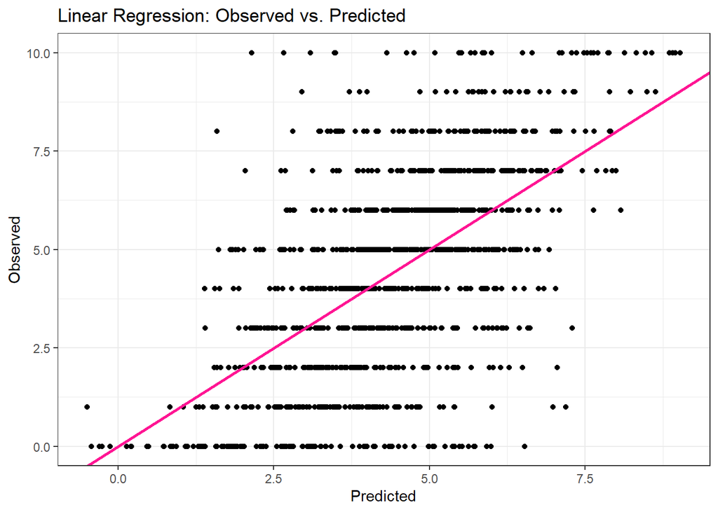

```r
ggplot(test_results, aes(x = alm, y = original)) +
  geom_point() +
  labs(title = "Linear Regression: Observed vs. Predicted",
       x = "Predicted", y = "Observed") +
  geom_abline(intercept = 0, slope = 1, colour = "deeppink1", linewidth = 1) +
  theme_bw()
```

The plot remains identical.